# Stat542: Variable Selection

Fall 2022

## Load Data

The **Prostate data** can be found [[here](https://hastie.su.domains/ElemStatLearn/data.html)]. The data is to examine the correlation between the level of prostate-specific antigen and a number of clinical measures in men who were about to receive a radical prostatectomy.

- `lcavol`: log cancer volume
- `lweight`: log prostate weight
- `age`: in years
- `lbph`: log of the amount of benign prostatic hyperplasia
- `svi`: seminal vesicle invasion
- `lcp`: log of capsular penetration
- `gleason`: a numeric vector
- `pgg45`: percent of Gleason score 4 or 5
- `lpsa`: response

The first 8 columns are predictors; column 9 is the outcome/response. We do not use column 10, which indicates which 67 observations were used as the “training set” and which 30 as the test set, as described on page 48 in the ESL book. For convenience, we rename the response column with a generic name Y.

```r
myData = read.table(file = "https://hastie.su.domains/ElemStatLearn/datasets/prostate.data", header = TRUE)
names(myData)
myData = myData[, -10]
names(myData)[9] = 'Y'
n = dim(myData)[1]         # sample size
p = dim(myData)[2] - 1     # number of non-intercept predictors
```

## Full Model

```r
full.model = lm( Y ~ ., data = myData);
summary(full.model)
```

```
Call:
lm(formula = Y ~ ., data = myData)

Residuals:
     Min       1Q   Median       3Q      Max
-1.76644 -0.35510 -0.00328  0.38087  1.55770

Coefficients:
             Estimate Std. Error t value Pr(>|t|)
(Intercept)  0.181561   1.320568   0.137  0.89096
lcavol       0.564341   0.087833   6.425 6.55e-09 ***
lweight      0.622020   0.200897   3.096  0.00263 **
age         -0.021248   0.011084  -1.917  0.05848 .
lbph         0.096713   0.057913   1.670  0.09848 .
svi          0.761673   0.241176   3.158  0.00218 **
lcp         -0.106051   0.089868  -1.180  0.24115
gleason      0.049228   0.155341   0.317  0.75207
pgg45        0.004458   0.004365   1.021  0.31000
---
Signif. codes:  0 ‘***’ 0.001 ‘**’ 0.01 ‘*’ 0.05 ‘.’ 0.1 ‘ ’ 1

Residual standard error: 0.6995 on 88 degrees of freedom
Multiple R-squared:  0.6634,    Adjusted R-squared:  0.6328
F-statistic: 21.68 on 8 and 88 DF,  p-value: < 2.2e-16
```

## Level-wise Algorithm

**First**, for each size (from 1 to p), find the variable set (of that size) that produces the smallest RSS.

```r
# install.packages("leaps")
library(leaps)
b = regsubsets(Y ~ ., data=myData, nvmax = p)
rs = summary(b)
rs$which
```

```
  (Intercept) lcavol lweight   age  lbph   svi   lcp gleason pgg45
1        TRUE   TRUE   FALSE FALSE FALSE FALSE FALSE   FALSE FALSE
2        TRUE   TRUE    TRUE FALSE FALSE FALSE FALSE   FALSE FALSE
3        TRUE   TRUE    TRUE FALSE FALSE  TRUE FALSE   FALSE FALSE
4        TRUE   TRUE    TRUE FALSE  TRUE  TRUE FALSE   FALSE FALSE
5        TRUE   TRUE    TRUE  TRUE  TRUE  TRUE FALSE   FALSE FALSE
6        TRUE   TRUE    TRUE  TRUE  TRUE  TRUE FALSE   FALSE  TRUE
7        TRUE   TRUE    TRUE  TRUE  TRUE  TRUE  TRUE   FALSE  TRUE
8        TRUE   TRUE    TRUE  TRUE  TRUE  TRUE  TRUE    TRUE  TRUE
```

**Second**, compute the model selection score (AIC/BIC) for those p models and find the one that achieves the the smallest score.

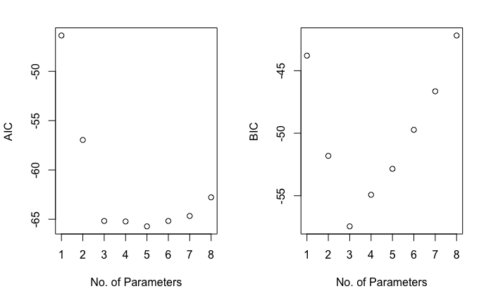

```r
msize = 1:p;
par(mfrow=c(1,2))
Aic = n*log(rs$rss/n) + 2*msize;
Bic = n*log(rs$rss/n) + msize*log(n)
plot(msize, Aic, xlab="No. of Parameters", ylab = "AIC")
plot(msize, Bic, xlab="No. of Parameters", ylab = "BIC")
```

For this particular data set, AIC and BIC end up selecting different models. The model selected by AIC is larger than the one selected by BIC, which is common. (AIC favors larger models while BIC favors smaller models.) Although the model selected by BIC does not have the smallest AIC score, its AIC score is very close to the smallest one.

```r
cbind(rs$which[which.min(Aic),], rs$which[which.min(Bic), ])
```

```
             [,1]  [,2]
(Intercept)  TRUE  TRUE
lcavol       TRUE  TRUE
lweight      TRUE  TRUE
age          TRUE FALSE
lbph         TRUE FALSE
svi          TRUE  TRUE
lcp         FALSE FALSE
gleason     FALSE FALSE
pgg45       FALSE FALSE
```

`leaps` does not return AIC, but BIC. Its BIC differs from what has been computed above, but the difference is a constant, so the two BIC formulas (ours and the one used by leaps) are essentially the same.

```r
cbind(rs$bic, Bic, rs$bic - Bic)
```

[output not shown]

> What are the 2nd and 3rd best models in terms of AIC/BIC?

This cannot be answered by looking at the AIC/BIC plots shown above. Instead, we need to run the following code.

```r
# ?regsubsets
b = regsubsets(Y ~ ., data=myData, nbest = 3, nvmax = p)
rs = summary(b)
rs$which
msize = apply(rs$which, 1, sum) - 1
```

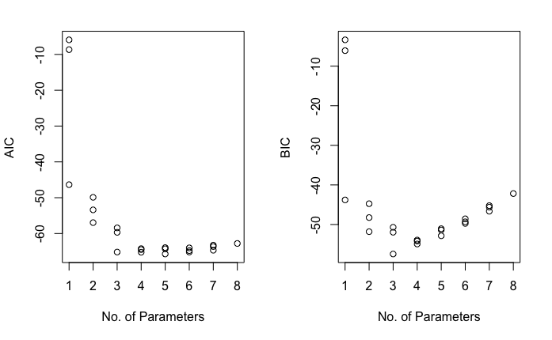

```r
par(mfrow=c(1,2))
Aic = n*log(rs$rss/n) + 2*msize
Bic = n*log(rs$rss/n) + msize*log(n)
plot(msize, Aic, xlab="No. of Parameters", ylab = "AIC")
plot(msize, Bic, xlab="No. of Parameters", ylab = "BIC")
```

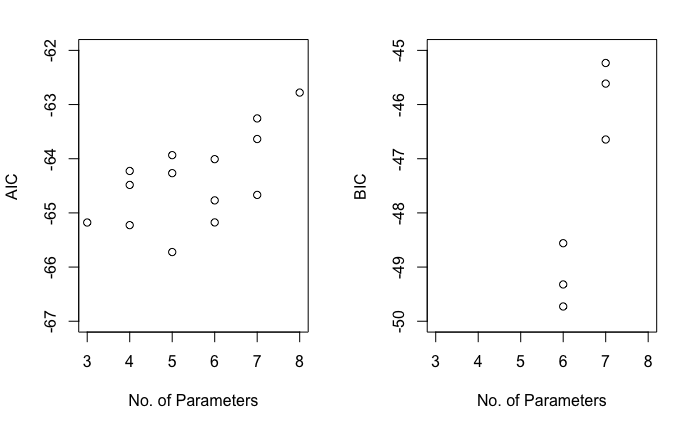

```r
plot(msize[msize > 2], Aic[msize > 2], ylim = c(-67, -62), xlab="No. of Parameters", ylab = "AIC")
plot(msize[msize > 2], Bic[msize > 2], ylim = c(-50, -45), xlab="No. of Parameters", ylab = "BIC")
```

```r
# top three models by AIC
rs$which[order(Aic)[1:3],]
```

```
  (Intercept) lcavol lweight   age  lbph  svi   lcp gleason pgg45
5        TRUE   TRUE    TRUE  TRUE  TRUE TRUE FALSE   FALSE FALSE
4        TRUE   TRUE    TRUE FALSE  TRUE TRUE FALSE   FALSE FALSE
3        TRUE   TRUE    TRUE FALSE FALSE TRUE FALSE   FALSE FALSE
```

```r
# top three models by BIC
rs$which[order(Bic)[1:3],]
```

```
  (Intercept) lcavol lweight   age  lbph  svi   lcp gleason pgg45
3        TRUE   TRUE    TRUE FALSE FALSE TRUE FALSE   FALSE FALSE
4        TRUE   TRUE    TRUE FALSE  TRUE TRUE FALSE   FALSE FALSE
4        TRUE   TRUE    TRUE  TRUE FALSE TRUE FALSE   FALSE FALSE
```

## Stepwise Algorithm

### Stepwise AIC

Set `trace=0` if you do not want to see the intermediate results

```r
#stepAIC = step(full.model, trace=0, direction="both")
stepAIC = step(full.model, direction="both")
```

```
Start:  AIC=-60.78
Y ~ lcavol + lweight + age + lbph + svi + lcp + gleason + pgg45

          Df Sum of Sq    RSS     AIC
- gleason  1    0.0491 43.108 -62.668
- pgg45    1    0.5102 43.569 -61.636
- lcp      1    0.6814 43.740 -61.256
<none>                 43.058 -60.779
- lbph     1    1.3646 44.423 -59.753
- age      1    1.7981 44.857 -58.810
- lweight  1    4.6907 47.749 -52.749
- svi      1    4.8803 47.939 -52.364
- lcavol   1   20.1994 63.258 -25.467

Step:  AIC=-62.67
Y ~ lcavol + lweight + age + lbph + svi + lcp + pgg45

          Df Sum of Sq    RSS     AIC
- lcp      1    0.6684 43.776 -63.176
<none>                 43.108 -62.668
- pgg45    1    1.1987 44.306 -62.008
- lbph     1    1.3844 44.492 -61.602
- age      1    1.7579 44.865 -60.791
+ gleason  1    0.0491 43.058 -60.779
- lweight  1    4.6429 47.751 -54.746
- svi      1    4.8333 47.941 -54.360
- lcavol   1   21.3191 64.427 -25.691

Step:  AIC=-63.18
Y ~ lcavol + lweight + age + lbph + svi + pgg45

          Df Sum of Sq    RSS     AIC
- pgg45    1    0.6607 44.437 -63.723
<none>                 43.776 -63.176
+ lcp      1    0.6684 43.108 -62.668
- lbph     1    1.3329 45.109 -62.266
- age      1    1.4878 45.264 -61.934
+ gleason  1    0.0362 43.740 -61.256
- svi      1    4.1766 47.953 -56.336
- lweight  1    4.6553 48.431 -55.373
- lcavol   1   22.7555 66.531 -24.572

Step:  AIC=-63.72
Y ~ lcavol + lweight + age + lbph + svi

          Df Sum of Sq    RSS     AIC
<none>                 44.437 -63.723
- age      1    1.1588 45.595 -63.226
+ pgg45    1    0.6607 43.776 -63.176
+ gleason  1    0.4767 43.960 -62.769
- lbph     1    1.5087 45.945 -62.484
+ lcp      1    0.1304 44.306 -62.008
- lweight  1    4.3140 48.751 -56.735
- svi      1    5.8509 50.288 -53.724
- lcavol   1   25.9427 70.379 -21.119
```

### Stepwise BIC

```r
n = dim(myData)[1]
stepBIC = step(full.model, direction="both", k=log(n))
```

```
Start:  AIC=-37.61
Y ~ lcavol + lweight + age + lbph + svi + lcp + gleason + pgg45

          Df Sum of Sq    RSS     AIC
- gleason  1    0.0491 43.108 -42.071
- pgg45    1    0.5102 43.569 -41.039
- lcp      1    0.6814 43.740 -40.658
- lbph     1    1.3646 44.423 -39.155
- age      1    1.7981 44.857 -38.213
<none>                 43.058 -37.606
- lweight  1    4.6907 47.749 -32.151
- svi      1    4.8803 47.939 -31.767
- lcavol   1   20.1994 63.258  -4.869

Step:  AIC=-42.07
Y ~ lcavol + lweight + age + lbph + svi + lcp + pgg45

          Df Sum of Sq    RSS     AIC
- lcp      1    0.6684 43.776 -45.153
- pgg45    1    1.1987 44.306 -43.985
- lbph     1    1.3844 44.492 -43.579
- age      1    1.7579 44.865 -42.768
<none>                 43.108 -42.071
+ gleason  1    0.0491 43.058 -37.606
- lweight  1    4.6429 47.751 -36.723
- svi      1    4.8333 47.941 -36.337
- lcavol   1   21.3191 64.427  -7.668

Step:  AIC=-45.15
Y ~ lcavol + lweight + age + lbph + svi + pgg45

          Df Sum of Sq    RSS     AIC
- pgg45    1    0.6607 44.437 -48.274
- lbph     1    1.3329 45.109 -46.818
- age      1    1.4878 45.264 -46.486
<none>                 43.776 -45.153
+ lcp      1    0.6684 43.108 -42.071
- svi      1    4.1766 47.953 -40.888
+ gleason  1    0.0362 43.740 -40.658
- lweight  1    4.6553 48.431 -39.924
```

[output cut: 28 more lines]

```
- lcavol   1   24.9384 70.534 -12.607

Step:  AIC=-52.88
Y ~ lcavol + lweight + svi

          Df Sum of Sq    RSS     AIC
<none>                 46.568 -52.879
+ lbph     1    0.9730 45.595 -50.352
+ age      1    0.6230 45.945 -49.610
+ pgg45    1    0.5007 46.068 -49.352
+ gleason  1    0.3445 46.224 -49.024
+ lcp      1    0.0694 46.499 -48.448
- svi      1    5.1737 51.742 -47.234
- lweight  1    7.1089 53.677 -43.673
- lcavol   1   24.7058 71.274 -16.169
```

### Retrieve Results

How to retrieve the output from those step-wise procedures?

```r
sel.var.AIC = attr(stepAIC$terms, "term.labels")
sel.var.BIC = attr(stepBIC$terms, "term.labels")
sel.var.AIC
length(sel.var.AIC)
length(sel.var.BIC)
c("age", "lcp") %in% sel.var.AIC
sel.var.BIC %in% sel.var.AIC
```